# Identification des tendances de sécheresse hydrologique dans le département 59

Baptiste ROUSSEL

2025-07-28

# I) Introduction

La gestion quantitative de la ressource en eau devient un enjeu majeur dans notre actualité. Les tensions sur les usages s’accentuent dans toutes les régions de France. Dans un contexte de changement climatique qui s’intensifie, la région des Hauts-de-France est de plus en plus impactée par des épisodes de sécheresse intense. Les Hauts-de-France doivent donc adapter leurs stratégies de gestion de l’eau pour faire face à ces défis. Cela suppose une bonne connaissance des milieux, la mise en place de plans de gestion des ressources en eau, la promotion de pratiques agricoles durables et l’amélioration des infrastructures de distribution de l’eau. Il existe quatre grands types de sécheresse : météorologique (relative aux précipitations), agricole (relative à l’humidité du sol), hydrologique (relative aux débits des cours d’eau) et socio-économique (relative aux dégâts économiques significatifs). La sécheresse hydrologique est caractérisée par un manque d’eau dans les cours d’eau qui peut survenir du fait d’une faible recharge du cours d’eau (précipitations, nappes souterraines), d’évaporation accrue par des fortes températures ou de prélèvements en eau plus élevés que ce que le milieu peut fournir (Ciesielski et Cabral, 2022). Ce phénomène est déjà observable dans plusieurs régions de France (Lespinas et al., 2010 ; Giuntoli et al., 2013 ; Ducharne et al., 2010). La sécheresse hydrologique dans les Hauts-de-France est un phénomène de plus en plus préoccupant. Il provoque une augmentation de la fréquence des problèmes de sécheresse (DREAL Hauts-de-France). Cette région, traditionnellement caractérisée par un climat tempéré et des précipitations régulières, subit désormais les effets du changement climatique, entraînant des périodes prolongées de déficit hydrique. C’est ce qui a pu être constaté lors de l’été 2022, avec une augmentation du nombre de cours d’eau en assecs surveillés par les agents de l’Office Français de la Biodiversité (OFB) dans le cadre du réseau de l’observatoire national des étiages (Observatoire national des étiages, 2022). Cette sécheresse prolongée a entrainé la mise en place de nombreux arrêtés de restrictions d’usages de l’eau par les préfets des départements (DREAL Hauts-de-France, 2022).

Ce document a pour but d’identifier des éventuelles tendances de sécheresse hydrologique à l’échelle d’un département ou d’une région, via le calcul de deux indicateurs issus de données de débits journalières :

- la durée de sécheresse (en jours)
- le VCN10 annuel (calculé sur les débits spécifiques), donnant une indication sur la sévérité des sécheresses

Dans cette étude sont utilisés les « débits journaliers influencés » qui désignent les variations du débit d’un cours d’eau modifiés par des interventions humaines ou des facteurs externes, tels que les barrages, les retenues d’eau, les pompages agricoles ou industriels, ainsi que les rejets d’eaux usées. Contrairement aux débits naturels, ces débits ne dépendent pas uniquement des précipitations et des conditions hydrologiques, mais aussi des activités humaines qui peuvent accentuer ou atténuer les fluctuations journalières du niveau d’eau dans une rivière ou un fleuve.

# II) Récupération des chroniques de débits

Dans cette étude, nous allons utiliser les données de débit des stations hydrométriques du département 59. Les informations concernant les stations et leurs chroniques sont bancarisées dans l’hydroportail. Elles sont récupérées à partir de l’API Hydrométrie de Hub’eau. Les stations hydrométriques sont des points de mesure permettant de surveiller en temps réel ou en différé les débits et niveaux des cours d’eau en France. Ces stations sont équipées de capteurs qui mesurent plusieurs paramètres hydrologiques :

- **Le niveau de l’eau** (hauteur hydrométrique)
- **Le débit** (volume d’eau écoulé par seconde)
- **La température de l’eau** (dans certains cas)

Certaines stations hydrométriques ont des séries de données incomplètes sur la chronologie étudiée (2000-2024). Cela s’explique par des problèmes matériels mais aussi organisationnel avec le déplacement ou l’arrêt de certaines stations hydrométriques. Un filtre a donc été appliqué pour ne retenir que les stations ayant une bonne complétude de données.

# III) Calcul des seuils de sécheresse

Le calcul des seuils de sécheresse est une étape cruciale dans la gestion des ressources en eau et donc la prévention des impacts négatifs liés à la sécheresse. En effet, les seuils de sécheresse, sur lesquels sont basées les règles de gestion conjoncturelle fixées par arrêté préfectoral à l’échelle départementale, déterminent les différents niveaux à partir desquels des mesures de gestion des ressources en eau peuvent être appliquées (restrictions d’usage notamment). Dans cette étude, la sécheresse sera définie comme le débit étant strictement inférieur à un débit seuil de sécheresse établi. Ce seuil a été choisi égal à une fréquence au dépassement du Q90. Le “Q90” en hydrologie fait référence à un débit caractéristique des basses eaux d’un cours d’eau. Il s’agit du débit qui est dépassé 90 % du temps, ce qui signifie que pendant 90 % de la période de l’étude, le débit du cours d’eau est supérieur à cette valeur. Le Q90 est un indicateur important pour la gestion des ressources en eau, notamment pour la détermination des débits réservés et la planification de l’utilisation de l’eau en période de sécheresse. Il est calculé à partir des données de débit journalier sur une période de référence, généralement plusieurs dizaines années, afin de fournir une estimation fiable des conditions de basses eaux.

Valeurs du Q90 pour les stations hydrométriques du département 59 entre le 01-01-2000 et le 31-12-2024

| Ligne | Station Hydrometrique | Code de la station | Q90(l/s) |
| --- | --- | --- | --- |
| 1 | L'Helpe Mineure à Étrœungt | D013701001 | 268.40 |
| 2 | L'Helpe Mineure à Maroilles | D013702001 | 484.90 |
| 3 | L'Helpe Mineure à Fourmies | D013705001 | 51.18 |
| 4 | L'Helpe Majeure à Liessies | D015651001 | 293.78 |
| 5 | L'Helpe Majeure à Taisnières-en-Thiérache | D015652001 | 506.86 |
| 6 | L'Helpe Majeure à Flaumont-Waudrechies | D015656001 | 354.28 |
| 7 | La Tarsy à Monceau-Saint-Waast [La Brasserie] | D015850001 | 140.72 |
| 8 | Le ruisseau de Montbliard à Eppe-Sauvage | D015850501 | 16.32 |
| 9 | La Sambre canalisée à Marpent | D019223001 | 2,122.81 |
| 10 | La Flamenne à Maubeuge [Douzies] | D019701001 | 21.13 |
| 11 | La Solre à Ferrière-la-Grande | D020601001 | 343.88 |
| 12 | La Solre à Choisies | D020602001 | 209.94 |
| 13 | L'Escaut canalisée à Iwuy | E131000202 | 2,039.65 |
| 14 | La Selle à Denain et à Noyelles-sur-Selle | E172601002 | 1,444.22 |
| 15 | L'Ecaillon à Thiant | E172751001 | 567.31 |
| 16 | La Rhonelle à Aulnoy-lez-Valenciennes | E176601001 | 264.62 |
| 17 | La Hogneau à Gussignies | E182701002 | 142.97 |
| 18 | La Hogneau à Thivencelle | E182702001 | 459.28 |
| 19 | L'Aunelle à Rombies-et-Marchipont | E182702602 | 118.47 |
| 20 | Le courant de Coutiches à Flines-lez-Raches | E236741001 | 21.21 |
| 21 | La Scarpe canalisée à Mortagne-du-Nord | E237110501 | 1,878.31 |
| 22 | Le courant de l'Hôpital à Bousignies | E237601001 | 68.50 |
| 23 | L'Elnon à Lecelles | E237721001 | 42.89 |
| 24 | L'Escaut canalisée à Maulde | E240041101 | 10,964.99 |
| 25 | La Marque à Bouvines | E334601001 | 154.38 |
| 26 | Le canal de la Deule à Wambrechies | E341210001 | 3,960.00 |
| 27 | La Lys à Armentières | E367125002 | 3,216.42 |
| 28 | La Lys à Bousbecque | E381126501 | 7,877.28 |
| 29 | Longue Becque à Renescure | E400000101 | 6.11 |
| 30 | L'Yser à Bambecque | E490571001 | 105.09 |
| 31 | L'Yser à Bollezeele [Erkelsbrug] | E490571101 | 3.67 |
| 32 | L'Ey Becque à Houtkerque | E490941401 | 39.22 |

# IV) Calcul des indicateurs de sécheresse

## 1) Durée de la sécheresse

La durée de la sécheresse hydrologique peut varier en fonction de plusieurs facteurs, notamment le climat, la saison, la nature du sol et la végétation. La sécheresse hydrologique se caractérise par des niveaux anormalement bas des lacs, rivières, cours d’eau ou nappes souterraines, souvent en raison d’un manque de pluie prolongé ou d’une utilisation excessive des ressources en eau. La durée de la sécheresse est ici assimilée au nombre de jours dans l’année présentant un débit strictement inférieur au seuil de sécheresse (Q90) sur une période allant de 01-01-2000 à 31-12-2024. Ce seuil de sécheresse est déterminé dans la partie précédente pour chaque station du département.

Les tendances éventuelles de sécheresse peuvent dans un premier temps être étudiées graphiquement à l’échelle du département :

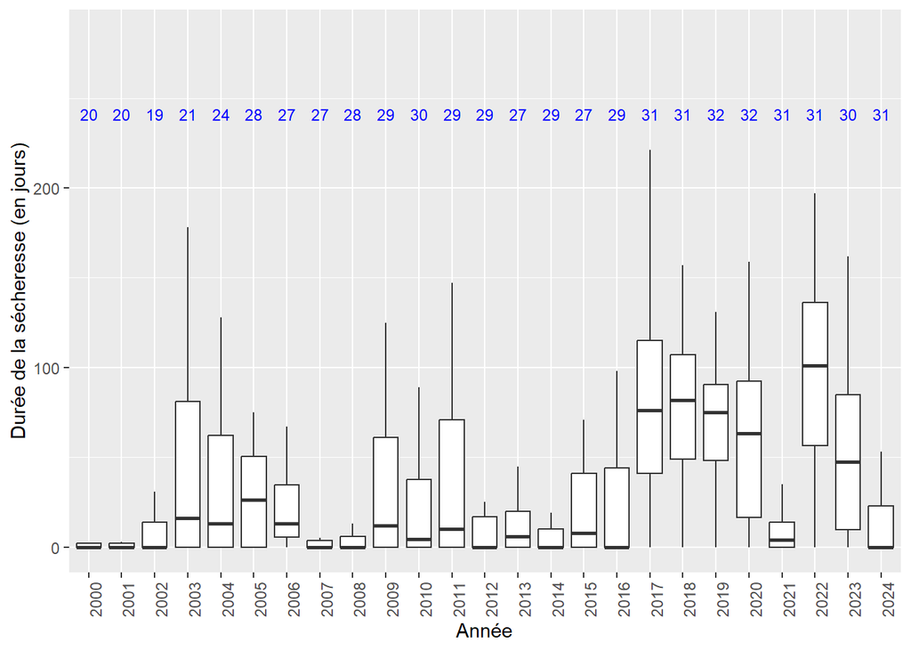

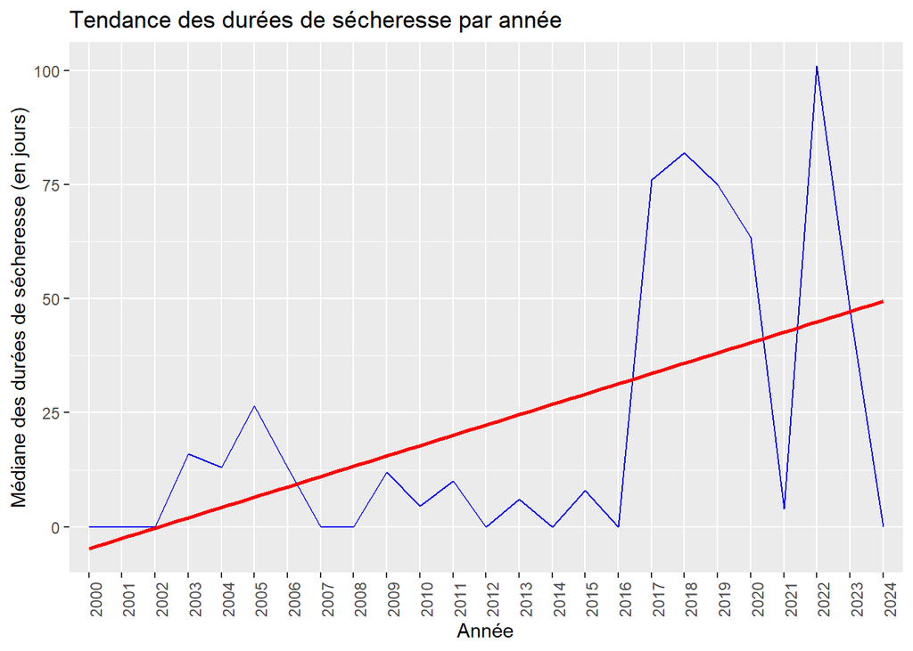

## 2) VCN10

Le VCN10 en hydrologie désigne le débit minimum moyen sur 10 jours consécutifs sur une année. Cet indicateur permet de caractériser les périodes de basses eaux des cours d’eau. Le VCN10 est pertinent pour évaluer la disponibilité minimale en eau sur une courte durée, ce qui est important pour la gestion des ressources en eau, surtout en période de sécheresse. Ils seront calculés à partir des débits spécifiques de chaque station (débits réels divisées par la surface du bassin versant amont), afin de pouvoir comparer ces VCN10 et les agréger. Les surfaces de bassins versants amonts sont disponibles via l’API hydrometrie de Hub’eau. Pour établir le VCN10, on se base sur des données de débit recueillies sur une période suffisamment longue, souvent plusieurs décennies, afin d’assurer une estimation fiable des conditions de basses eaux. Ce graphique 3 ci-dessous, représente la médiane annuelle des valeurs VCN10 pour toutes les stations du département du Nord sur une période allant de l’année 01-01-2000 à 31-12-2024.

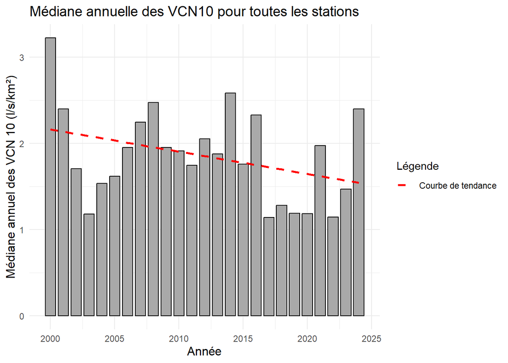

# IV) Tendances de sécheresse

Le but de cette partie est de déterminer si les indicateurs de sécheresse suivent une tendance monotone significative (une tendance monotone fait référence à une séquence ou une fonction qui ne change pas de direction). Une tendance monotone significative peut donc indiquer un changement dans les ressources en eau, influencé par des facteurs tels que le changement climatique, les pratiques de gestion de l’eau ou les modifications de l’utilisation des terres. Dans cette étude, les tendances sont étudiées grâce à un test de Mann-Kendal (tendance monotone significative ou non) et un test de Sen-Theil (pente de la droite de tendance : positive, négative ou nulle, qui détermine s’il y a une dégradation ou une amélioration).

Cependant, il est important de souligner que ces tests sont sensibles à la présence importante de valeurs nulles dans les données. En particulier, le test de Mann-Kendal, reposant sur le classement des observations, peut conclure à une absence de tendance en cas de nombreuses valeurs constantes, en l’occurence 0. Cela peut masquer une éventuelle évolution réelle. De son côté, le test de Sen-Theil calcule une pente médiane entre paires d’années. Ainsi, si un grand nombre d’années présentent une pente nulle, la pente médiane en est inévitablement affectée. De cette manière, une tendance à la sécheresse serait écrasée par la quantité importante de pentes nulles. Par ailleurs, si les années les plus récentes sont dominées par des valeurs nulles, les tests seront facilement influencés pour prédire une amélioration. Il est donc primordial de prendre les résultats de ces statistiques avec prudence, une absence de tendance ne signifiant pas une absence de sécheresse significative, ni une stabilité des conditions hydrologiques.

## 2) Tendance sur les VCN10

Le but de cette partie est de déterminer s’il existe une tendance monotone pour les VCN10 des stations du département 59. Ces tendances sont étudiées grâce à un test de Mann-Kendal et un test de Sen-Theil.

Tendance du VCN10 sur les stations hydrométriques du département 59 entre le 01-01-2000 et le 31-12-2024

| Ligne | Station Hydrometrique | Code de la station | P value | Sens de la pente | Tendance |
| --- | --- | --- | --- | --- | --- |
| 1 | L'Helpe Mineure à Fourmies | D013705001 | 0.00006505027 | -0.083368172 | Dégradation |
| 2 | La Solre à Ferrière-la-Grande | D020601001 | 0.00471404500 | -0.128485428 | Dégradation |
| 3 | L'Ecaillon à Thiant | E172751001 | 0.00221706158 | -0.087817539 | Dégradation |
| 4 | La Rhonelle à Aulnoy-lez-Valenciennes | E176601001 | 0.01090615103 | -0.064059470 | Dégradation |
| 5 | Le courant de l'Hôpital à Bousignies | E237601001 | 0.01432574254 | -0.056969697 | Dégradation |
| 6 | La Marque à Bouvines | E334601001 | 0.00031989972 | -0.053624339 | Dégradation |
| 7 | La Lys à Bousbecque | E381126501 | 0.03433985001 | -0.155318194 | Dégradation |
| 8 | L'Yser à Bambecque | E490571001 | 0.00795270629 | -0.018927549 | Dégradation |
| 9 | L'Yser à Bollezeele [Erkelsbrug] | E490571101 | 0.00370439504 | -0.019212963 | Dégradation |
| 10 | L'Helpe Mineure à Étrœungt | D013701001 | 0.27234271223 | 0.009757835 | Pas de tendance |
| 11 | L'Helpe Mineure à Maroilles | D013702001 | 0.10707235212 | -0.023432778 | Pas de tendance |
| 12 | L'Helpe Majeure à Liessies | D015651001 | 0.55919776585 | 0.017405203 | Pas de tendance |
| 13 | L'Helpe Majeure à Taisnières-en-Thiérache | D015652001 | 0.76142153615 | 0.003080357 | Pas de tendance |
| 14 | L'Helpe Majeure à Flaumont-Waudrechies | D015656001 | 0.06904431985 | -0.027636719 | Pas de tendance |
| 15 | La Tarsy à Monceau-Saint-Waast [La Brasserie] | D015850001 | 0.31525155540 | 0.033304652 | Pas de tendance |
| 16 | Le ruisseau de Montbliard à Eppe-Sauvage | D015850501 | 0.64042878741 | 0.004574682 | Pas de tendance |
| 17 | La Sambre canalisée à Marpent | D019223001 | 0.11188667490 | -0.062414530 | Pas de tendance |
| 18 | La Flamenne à Maubeuge [Douzies] | D019701001 | 0.74355591112 | -0.002951389 | Pas de tendance |
| 19 | La Solre à Choisies | D020602001 | 0.08821070970 | -0.045628019 | Pas de tendance |
| 20 | La Selle à Denain et à Noyelles-sur-Selle | E172601002 | 0.62381243607 | -0.031559001 | Pas de tendance |
| 21 | La Hogneau à Gussignies | E182701002 | 0.58125476041 | 0.013186813 | Pas de tendance |
| 22 | La Hogneau à Thivencelle | E182702001 | 0.16822084691 | -0.039761364 | Pas de tendance |
| 23 | L'Aunelle à Rombies-et-Marchipont | E182702602 | 0.05517961632 | -0.049878501 | Pas de tendance |
| 24 | Le courant de Coutiches à Flines-lez-Raches | E236741001 | 0.16101069768 | -0.005439560 | Pas de tendance |
| 25 | La Scarpe canalisée à Mortagne-du-Nord | E237110501 | 0.77028772647 | 0.030821508 | Pas de tendance |
| 26 | L'Elnon à Lecelles | E237721001 | 0.76187339478 | -0.008163265 | Pas de tendance |
| 27 | L'Escaut canalisée à Maulde | E240041101 | 0.16168621659 | -0.106746657 | Pas de tendance |
| 28 | Le canal de la Deule à Wambrechies | E341210001 | 0.83681970505 | -0.021529091 | Pas de tendance |
| 29 | La Lys à Armentières | E367125002 | 0.62649627435 | -0.023357415 | Pas de tendance |

Le pourcentage de stations dont le VCN10 diminue significativement durant la période 01-01-2000 à 31-12-2024 est de 31 %.